# 2 Fitting models to data

in the previous section, you were given a linear model - we knew the values of $\alpha$, $\beta$ and even $\sigma$. However, in most contexts we don’t know the true relationship between $X$ and $Y$ in advance. Instead, we are given *data* and try to *infer* the values of $\alpha$, $\beta$, and $\sigma$ by analysing the data.

Indeed, at the end of the last session we generated data from a linear model. In preparation for this chapter, we’ve generated data from a similar such linear model. Here it is:

**Plot**

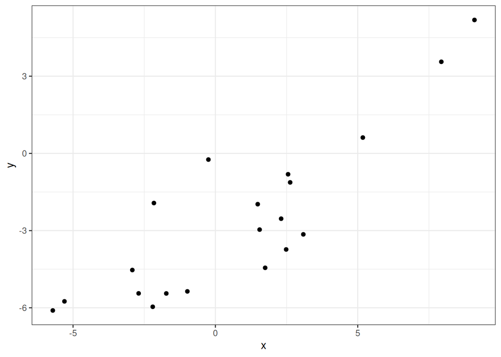

**Data**

```
            x          y
1  -2.1599284 -1.9291238
2  -5.7113731 -6.1040414
3  -2.9177531 -4.5324312
4   9.1000397  5.1856701
5  -1.7243658 -5.4432479
6   1.7480502 -4.4459260
7  -0.9846129 -5.3624188
8   2.5525718 -0.8108359
9   3.0885763 -3.1464855
10  2.3093400 -2.5379876
11  2.6262036 -1.1267256
12  7.9357609  3.5601225
13  5.1785875  0.6154300
14 -5.3016608 -5.7504378
15  1.5531532 -2.9618749
16 -2.6965314 -5.4399582
17  2.4854759 -3.7328958
18  1.4868730 -1.9733257
19 -2.2011595 -5.9606383
20 -0.2452917 -0.2402351
```

your task for the remainder of the chapter (and in regression generally) is to try an make a (educated) guess about what model produced this data.

- Continue

## 2.1 Estimating parameters

We call the process of trying to guess the parameters in the data generating model (i.e. $\alpha$, $\beta$ and $\sigma$), *estimation*, and our guesses are *estimates*. To avoid confusion, we’ll denote the estimated intercept by $a$ and the estimated slope by $b$. So, we have

$$a: \text{Estimated intercept}$$
$$b: \text{Estimated slope}$$
$$\hat{\sigma}: \text{Estimated standard deviation}.$$
We also define $\hat{Y}$ as the predicted value of $Y$ given our estimated model:
$$\hat{Y}=a+bX$$
Looking at some data, we try to find the values of our parameters that best ‘fit’ its distribution. Adjust the sliders below to find a line that you think fits the data:

[interactive chart not shown]

**Exercise 1**

What is your best estimate for the values of $\alpha$ and $\beta$ that best fit the given data?

### 2.1.1

Ok great, so we have an estimate for our line-of-best-fit:

[interactive chart not shown]

but what do we mean by ‘best’ fit here? How do we evaluate this estimate and maybe compare it to other estimates?

- Continue

## 2.2 Residuals

Residuals are the difference between observed values of $Y$, and the value predicted by our estimated linear predictor $\hat{Y}$. We denote residuals with the letter $e$:
$$e=Y-\hat{Y} = Y - (a + bX).$$

Residuals, $e$, are similar to the errors, $\varepsilon$, that we encountered in chapter 1 - but they are distinct. In many situations, we do not know the ‘acutual’ values of $\alpha$ and $\beta$ - so we cannot calculate the errors, $\varepsilon= Y- E[Y]= Y-\alpha + \beta X$. However, we do have our estimates, $a$ and $b$, so we can calculate residuals.

Indeed - calculating residuals gives us a way to assess how well our estimated model fits the data. We can think of the residuals as being the ‘mismatch’ between our estimated linear predictor and each data point. By *minimizing* the size of residuals (minimisiong the mismatch of our model to the data), we can get a better fit of our line to data.

- Continue

## 2.3 Estimating coefficients

### 2.3.1 Optimising model fit by minimising (squared) residuals

Below, the plot now also displays residuals for each data point. Underneath the model equation is the *Sum of Squared Residuals* (SSR), which gives a measure of the absolute difference between our linear predictor and the observed outcomes.

$$SSR=\sum_{i=1}^{n} e_i^2$$

where $e_i = Y_i - \hat{Y}_i$. This gives us a numerical measure of how well the line fits the data - see how low you can get the SSR by adjusting slope and intercept.

[interactive chart not shown]

**Exercise 2**

Based on this visualisation, what do you think is the minimum possible $SSR$ achievable?

If you want you can update your $a$ and $b$ estimates too (otherwise just proceed):

**Technical-point 1:** Why squares?**

The least squares estimator chooses $a$ and $b$ so that the sum of squared residuals $\sum_{i=1}^{n} e_i^2$ is as small as possible. But why take squares? As mentioned, squaring numbers returns a positive result. Therefore the square gives some idea of the ‘absolute’ value of the residuals (and doesn’t allow negative residuals to cancel out positve ones). But why not just take the absolute value? Because the square function penalises large deviations heavily, least squares prefers lines that keep every point reasonably close to the fitted value rather than letting a few points drift far away.

### 2.3.2 The least-squares estimate

We call the estimates $a$ and $b$ which minimise the sum of squares the *least squares estimates*. Some nice mathematics tells us that the least squares esimates for a simple linear model are *unique* - that is, there is one set of values for $a$ and $b$ which satisfy this property. Moreover, we don’t have to manually adjust our parameters to keep lowering SSR - there is a convenient closed form expression which allows us to compute $a$ and $b$ very efficiently. As a statistical programming language, this is something R does very easily..

### 2.3.3 Fitting a model with the `lm()` function

- Continue

## 2.4 Estimating variance

We can extract the individual residual values from the fitted `lm` object by indexing (e.g. `my_lm$residuals`) or with the `residuals()` function.

The resulting `R` object is a vector of the residual for each observation. i.e. residuals(lm_1)[[3]] $= e_3$

**Exercise 3:** Extracting residuals from an lm object**

Extract the residuals from your least squares fitted model `lm_1`*by indexing* and assign them to the variable `e`

### 2.4.2 Correlation and $R^2$

The coefficient, $r$, measures how strongly $X$ and $Y$ move together along a straight line, taking values between $-1$ (perfect negative linear relationship) and $1$ (perfect positive linear relationship).

In simple linear regression with an intercept, the value can be written as
$$R^2 = 1 - \frac{\text{RSS}}{\text{TSS}} = r^2,$$
so $R^2$ captures the proportion of the total variation in $Y$ that is explained by the fitted line.

**Exercise 4:** Correlation and $R^2$ in our example**

Calculate the correlation between `x` and `y`, then compute $R^2$ using the residuals from `lm_1`.